# Divorce_Prediction

## Comparing Bayes, Logistic, and KNN Classifiers on Marriage Dataset:

In this project, I will use several classifiers to analyze the marriages dataset for divorce prediction.

This dataset is about participants who completed the personal information form and a divorce predictors scale.

The data is a modified version of the publicly available at https://archive.ics.uci.edu/ml/datasets/Divorce+Predictors+data+set (by injecting noise so you will not get the exactly same results as on UCI website). There are 170 participants and 54 attributes (or predictor variables) that are all real-valued. The last column of the CSV file is label $y$ (1 means divorce, 0 means no divorce). Each column is for one feature (predictor variable), and each row is a sample (participant). A detailed explanation for each feature (predictor variable) can be found at the website link above. Our goal is to build a classifier using training data, such that given a test sample, we can classify (or essentially predict) whether its label is 0 (no divorce) or 1 (divorce).

We begin by loading up the dataset and any relevant packages and formatting the data properly as demonstrated in the code cell below:

```python
import numpy as np
import pandas as pd
import scipy as sp
import matplotlib.pyplot as plt
from sklearn.decomposition import PCA
from sklearn.neighbors import KNeighborsClassifier
from sklearn.naive_bayes import GaussianNB
from sklearn.linear_model import LogisticRegression
from mlxtend.plotting import plot_decision_regions
from sklearn.model_selection import train_test_split
mar_df = pd.read_csv('marriage.csv',header=None)
mar_array = np.array(mar_df)
marriage_data = mar_array[:,0:54]
marriage_labels = mar_array[:,54]
data_train,data_test,labels_train,labels_test = train_test_split(marriage_data,marriage_labels,test_size=.2)
```

With our data and labels as well as packages loaded properly we move onto fitting each of the three classifiers beginning with logistic regression.

### Logistic Regression Accuracy Over Many Random Seeds:

After formatting our data properly, we can split it into two sets one for model training and a left out set for model testing. We will use this splitting method in training and testing each of the models below. Additionally, because the splitting method involves randomly choosing observations, we will run 100 iterations of each model with varying but comparable random number generator seeds to better understand the model's adaptability to initial conditions. Now we input the training data into our logistic regression model then evaluate the accuracy of the model via the testing data. The result of each of these randomly initialized training and testing set iterations is displayed below with an accompanying line showing the average rate across all iterations.

```
Maximum Test Accuracy = 1.0
```

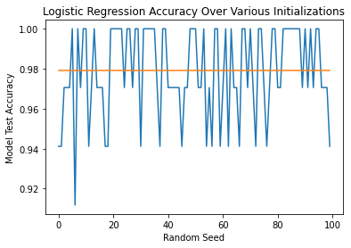

```python
def logistic_seeds():
    logistic_regression_accuracy_list = []
    for i in range(0,100):
        data_train,data_test,labels_train,labels_test = train_test_split(marriage_data,marriage_labels,test_size=.2,random_state=i)
        logistic_function = LogisticRegression(random_state=i).fit(data_train,labels_train)
        logistic_preds = logistic_function.predict(data_test)
        logistic_acc = np.sum(labels_test == logistic_preds)/labels_test.shape
        logistic_regression_accuracy_list.append(logistic_acc[0])
    return logistic_regression_accuracy_list
log_reg_seeded = logistic_seeds()
print('Maximum Test Accuracy = %s'%np.max(log_reg_seeded))
plt.plot(log_reg_seeded)
log_reg_average = np.average(log_reg_seeded)
average_list_log_1 = [log_reg_average]*100
plt.plot(np.array(average_list_log_1))
plt.title('Logistic Regression Accuracy Over Various Initializations')
plt.xlabel('Random Seed')
plt.ylabel('Model Test Accuracy')
plt.show()
```

As we can see from the chart output above, our logistic regression model does quite well generally at predicating divorces. We can see the chart shows some variability based upon the random seed used in the splitting step of our implementation, but overall the differences from iteration to iteration is fairly minimal suggesting we are somewhat robust to initial conditions with this dataset. Over all 100 different initializations our model comes out with an average accuracy rate of ~98%, which I found surprisingly high.

### Naive Bayes Accuracy Over Many Random Seeds:

We used the same procedures outlined above in preparing our Naive Bayes Classifier as shown below:

```
Maximum Test Accuracy = 1.0
```

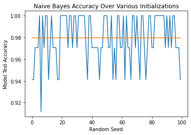

```python
def bayes_seeded(seeds):
    bayes_accuracy_list = []
    for i in range(0,seeds):
        data_train,data_test,labels_train,labels_test = train_test_split(marriage_data,marriage_labels,test_size=.2,random_state=i)
        bayes_model = GaussianNB().fit(data_train,labels_train)
        bayes_preds = bayes_model.predict(data_test)
        bayes_acc = np.sum(labels_test == bayes_preds)/labels_test.shape
        bayes_accuracy_list.append(bayes_acc[0])
    return bayes_accuracy_list
bayes_seeded = bayes_seeded(seeds=100)
bayes_seeded_avg = np.average(bayes_seeded)
bayes_seeded_avg_list = [bayes_seeded_avg]*100
print('Maximum Test Accuracy = %s'%np.max(bayes_seeded))
plt.plot(bayes_seeded)
plt.plot(bayes_seeded_avg_list)
plt.title('Naive Bayes Accuracy Over Various Initializations')
plt.xlabel('Random Seed')
plt.ylabel('Model Test Accuracy')
plt.show()
```

As we can see from the output above, we see largely the same result as the logistic regression implementation with only a few slight divergences in seeding. This could imply that our dataset is very linearly separable thus both classifiers would perform the task well.

### KNN Accuracy Over Many Random Seeds:

We used the same procedures outlined above in preparing our KNN Classifier as shown below:

```
Maximum Test Accuracy = 1.0
```

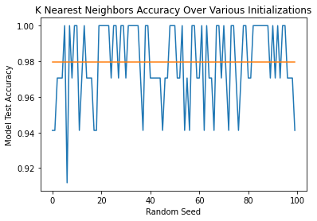

```python
def knn_seeded(seeds):
    knn_accuracy_list = []
    for i in range(0,seeds):
        data_train,data_test,labels_train,labels_test = train_test_split(marriage_data,marriage_labels,test_size=.2,random_state=i)
        knn_function = KNeighborsClassifier(n_neighbors=5).fit(data_train,labels_train)
        knn_preds = knn_function.predict(data_test)
        knn_acc = np.sum(labels_test == knn_preds)/labels_test.shape
        knn_accuracy_list.append(knn_acc[0])
    return knn_accuracy_list

knn_seeded = knn_seeded(seeds=100)
print('Maximum Test Accuracy = %s'%np.max(knn_seeded))
knn_seeded_avg = np.average(knn_seeded)
knn_seeded_avg_list = [knn_seeded_avg]*100

plt.plot(knn_seeded)
plt.plot(knn_seeded_avg_list)
plt.title('K Nearest Neighbors Accuracy Over Various Initializations')
plt.xlabel('Random Seed')
plt.ylabel('Model Test Accuracy')
plt.show()
```

Again, in the KNN model we see a largely similar result as the two prior implementations have shown. Given that each model was able to arrive at a consistent similar classifier accuracy level on the test data it is highly likely that our chosen dataset was very easily linearly separable, which would explain why each model performed nearly identically. Additionally, given that each model as the same average and highest accuracy it would be inappropriate without further testing to declare a single model the most appropriate.

Now, let's use the first two principal components of each to train three new classifiers. When reduced to this size of dimension, we can plot our decison boundaries. First, we must reformat and re-sample our data according to the first 2 PC Features. In order to prevent data leakage from our training to testing data sets, we will split the data first then apply PCA to the training data then project the testing data along this transformation before inputting it into the respective model. This is the procedure used for each of the following models in this section.

```python
marriage_data_2 = mar_array[:,0:2]
marriage_labels_2 = mar_array[:,54]
pca_model = PCA(n_components=2).fit(marriage_data_2.T)
marriage_data_2 = pca_model.components_.T
data_train_2,data_test_2,labels_train_2,labels_test_2 = train_test_split(marriage_data_2,marriage_labels_2,test_size=.2)
```

### Logistic Regression Classifier With PCA Reduction Test Accuracy Over Many Random Seeds:

```
Maximum Test Accuracy = 1.0
```

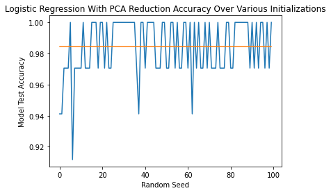

```python
def logistic_seeds_pca(seed):
    logistic_regression_accuracy_list2 = []
    for i in range(0,seed):
        data_train_2,data_test_2,labels_train_2,labels_test_2 = train_test_split(marriage_data,marriage_labels,test_size=.2,random_state=i)
        pca_mod = PCA(n_components=2).fit(data_train_2)
        data_train_2 = pca_mod.transform(data_train_2)
        data_test_2 =  pca_mod.transform(data_test_2)
        logistic_function_2 = LogisticRegression(random_state=i).fit(data_train_2,labels_train_2)
        logistic_preds_2 = logistic_function_2.predict(data_test_2)
        logistic_acc_2 = np.sum(labels_test_2 == logistic_preds_2)/labels_test_2.shape
        logistic_regression_accuracy_list2.append(logistic_acc_2)
    return logistic_regression_accuracy_list2
logistic_pca_accs = logistic_seeds_pca(100)
print('Maximum Test Accuracy = %s'%np.max(logistic_pca_accs))
logistic_pca_accs_avg = np.average(logistic_pca_accs)
logistic_pca_accs_avg_list = [logistic_pca_accs_avg]*100
plt.plot(logistic_pca_accs)
plt.plot(logistic_pca_accs_avg_list)
plt.title('Logistic Regression With PCA Reduction Accuracy Over Various Initializations')
plt.xlabel('Random Seed')
plt.ylabel('Model Test Accuracy')
plt.show()
```

### Logistic Regression Classifier With PCA Reduction Decision Boundary:

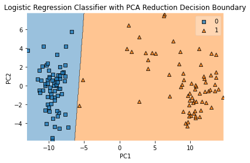

```python
data_train_2,data_test_2,labels_train_2,labels_test_2 = train_test_split(marriage_data,marriage_labels,test_size=.2,random_state=1)
pca_mod = PCA(n_components=2).fit(data_train_2)
data_train_2 = pca_mod.transform(data_train_2)
data_test_2 = pca_mod.transform(data_test_2)
logistic_function_2_dec = LogisticRegression(random_state=1).fit(data_train_2,labels_train_2)
plot_decision_regions(data_train_2,labels_train_2.astype(int),clf=logistic_function_2_dec,zoom_factor=10)

plt.xlabel('PC1')
plt.ylabel('PC2')
plt.title('Logistic Regression Classifier with PCA Reduction Decision Boundary')
plt.show()
```

Given the plot above it is pretty apparent that the application of PCA resulted in a very clear and easy to solve linear decision boundary which does a good job at seperation. Next we move onto Naive bayes with PCA preprocessing.

### Naive Bayes Classifier Test Accuracy Over Many Random Seeds With PCA Reduction:

```
Maximum Test Accuracy = 1.0
```

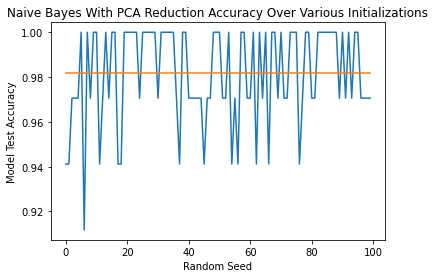

```python
def bayes_seeds_pca(seed):
    bayes_pca_acc_2 = []
    for i in range(0,seed):
        data_train_2,data_test_2,labels_train_2,labels_test_2 = train_test_split(marriage_data,marriage_labels,test_size=.2,random_state=i)
        pca_mod = PCA(n_components=2).fit(data_train_2)
        data_train_2 = pca_mod.transform(data_train_2)
        data_test_2 =  pca_mod.transform(data_test_2)
        bayes_model_2 = GaussianNB().fit(data_train_2,labels_train_2)
        bayes_preds_2 = bayes_model_2.predict(data_test_2)
        bayes_acc_2 = np.sum(labels_test_2 == bayes_preds_2)/labels_test_2.shape
        bayes_pca_acc_2.append(bayes_acc_2[0])
    return bayes_pca_acc_2

bayes_pca_accs = bayes_seeds_pca(100)
print('Maximum Test Accuracy = %s'%np.max(bayes_pca_accs))
bayes_pca_accs_avg = np.average(bayes_pca_accs)
bayes_pca_accs_avg_list = [bayes_pca_accs_avg]*100

plt.plot(bayes_pca_accs)
plt.plot(bayes_pca_accs_avg_list)
plt.title('Naive Bayes With PCA Reduction Accuracy Over Various Initializations')
plt.xlabel('Random Seed')
plt.ylabel('Model Test Accuracy')
plt.show()
```

Given the plot above we can see that our Naive Bayes implementation with PCA preprocessing did about the same as the non-preprocessed implementation discussed previously. It appears thus that the Naive Bayes model does not benefit from the addition of PCA transformation to the input data as we saw slightly in the logistic regression implementation.

### Naive Bayes Classifier With PCA Reduction Decision Boundary:

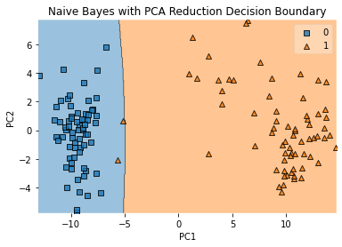

```python
data_train_2,data_test_2,labels_train_2,labels_test_2 = train_test_split(marriage_data,marriage_labels,test_size=.2,random_state=1)
pca_mod = PCA(n_components=2).fit(data_train_2)
data_train_2 = pca_mod.transform(data_train_2)
data_test_2 =  pca_mod.transform(data_test_2)
bayes_model_2_dec = GaussianNB().fit(data_train_2,labels_train_2)
plot_decision_regions(data_train_2,labels_train_2.astype(int),clf=bayes_model_2_dec,zoom_factor=20)

plt.xlabel('PC1')
plt.ylabel('PC2')
plt.title('Naive Bayes with PCA Reduction Decision Boundary')
plt.show()
```

As we can see from the decision boundary chart above, the Naive Bayes seems to have a boundary that is a bit more curved than the logistic regression boundary. This makes sense as the Bayes model is hinged on the gaussian distribution which gives rise to this shape of seperation plane.

### KNN Classifier With PCA Reduction Testing Accuracy Over Many Random Seeds:

```
Maximum Test Accuracy = 1.0
```

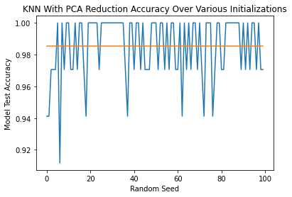

```python
def knn_seeds_pca(seed):
    knn_pca_acc_2 = []
    for i in range(0,seed):
        data_train_2,data_test_2,labels_train_2,labels_test_2 = train_test_split(marriage_data,marriage_labels,test_size=.2,random_state=i)
        pca_mod = PCA(n_components=2).fit(data_train_2)
        data_train_2 = pca_mod.transform(data_train_2)
        data_test_2 =  pca_mod.transform(data_test_2)
        knn_function_2 = KNeighborsClassifier(n_neighbors=2).fit(data_train_2,labels_train_2)
        knn_preds_2 = knn_function_2.predict(data_test_2)
        knn_acc_2 = np.sum(labels_test_2 == knn_preds_2)/labels_test_2.shape
        knn_pca_acc_2.append(knn_acc_2[0])
    return knn_pca_acc_2

knn_pca_accs = knn_seeds_pca(100)
print('Maximum Test Accuracy = %s'%np.max(knn_pca_accs))
knn_pca_accs_avg = np.average(knn_pca_accs)
knn_pca_accs_avg_list = [knn_pca_accs_avg]*100
plt.plot(knn_pca_accs)
plt.plot(knn_pca_accs_avg_list)
plt.title('KNN With PCA Reduction Accuracy Over Various Initializations')
plt.xlabel('Random Seed')
plt.ylabel('Model Test Accuracy')
plt.show()
```

As we can see from the plot above, our KNN classifier with PCA reduction performs nearly identically to our PCA reduced logistic regression model. Both experience a slightly higher average test accuracy when compared to their prior implementations.

### KNN Classifier With PCA Reduction Decision Boundary

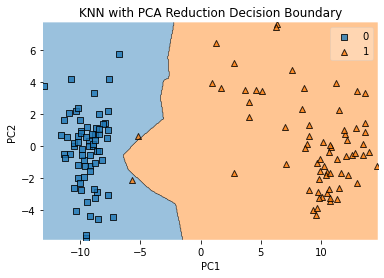

```python
data_train_2,data_test_2,labels_train_2,labels_test_2 = train_test_split(marriage_data,marriage_labels,test_size=.2,random_state=1)
pca_mod = PCA(n_components=2).fit(data_train_2)
data_train_2 = pca_mod.transform(data_train_2)
data_test_2 =  pca_mod.transform(data_test_2)
knn_function_2_dec = KNeighborsClassifier(n_neighbors=2).fit(data_train_2,labels_train_2)
plot_decision_regions(data_train_2,labels_train_2.astype(int),clf=knn_function_2_dec,zoom_factor=10)

plt.xlabel('PC1')
plt.ylabel('PC2')
plt.title('KNN with PCA Reduction Decision Boundary')
plt.show()
```

As we can see from the plot above, the KNN classifier takes a more irregular decision boundary which could fit training data better, but will prove a hinderance to testing out of sample data.

### Comparing Models:

Given all of our results shown above, I would if forced to choose between the models pick the logistic regression approach as the best model for a couple of reasons. Firstly, the logistic regression model with PCA reduction achieved the highest average percentage test accuracy tying with KNN with PCA reduction. The reason for choosing the logistic model over Knn in this scenario is twofold, the knn algorithm requires the tuning parameter of number of neighbors which alters this testing accuracy value and adds more complexity in properly applying the model. Additionally, the knn model as demonstrated in the decision boundary visualizations has a far more irregular seperation plane which although benefits training accuracy can hinder what important which is truly test accuracy.